# Exploring data from database: MySQL, R and dplyr

Mahbubul Majumder, PhD  
Nov 11, 2019

### Database management system

- Database is an organised collection of data
  - typically cleaned and structured data
- Database management system (DBMS)
  - allows to store, modify, and extract information from a database
  - `MySQL`, `ORACLE`, `MS SQL`, `DB2`, `MS ACCESS`, `Informix`
- RDBMS stands for Relational Database Management System
  - data is stored in database objects called tables
  - tables can be joined through keys and indexes
- SQL is used to work with DBMS

### What is SQL ?

- A standard language for accessing and manipulating data in databases
  - SQL stands for Structured Query Language
  - allows retrieving and manipulating data as well as administrative operations
  - common verbs are `SELECT`, `UPDATE`, `DELETE`, `INSERT`
  - administrative verbs `CREATE`, `ALTER`, `DROP`
  - common clauses and Keywords are `FROM`, `WHERE`, `GROUP BY`, `ORDER BY`
- A typical SQL command

```r
SELECT <column names seperated by comma>
  FROM <database table>
  WHERE <condition>
  GROUP BY <column name>
  ORDER BY <column name>
```

- You can do nesting or joining of two or more `SELECT` commands

### Accessing MySQL

- To connect MySQL, use the following command. Provide password when prompted

```r
mysql -u training -p
```

- To display the available databases the command is `show`. For example this code will display all the available databases for user training.

```r
show databases;
```

- To select a particular database, the command is `use`. For example we select the training `training` as follows

```r
use training;
```

- Once we select a database, we can view the tables

```r
show tables;

+----------------------+
| Tables_in_training |
+----------------------+
| hubstation           |
| hubway               |
| titanic              |
+----------------------+
3 rows in set (0.00 sec)
```

- Te get the description about a particular table use the following command. It will display column information of the specific table.

```r
describe titanic;
```

### About table titanic

```r
describe titanic;

+-----------+--------------+------+-----+---------+-------+
| Field     | Type         | Null | Key | Default | Extra |
+-----------+--------------+------+-----+---------+-------+
| pclass    | char(3)      | YES  |     | NULL    |       |
| survived  | char(1)      | YES  |     | NULL    |       |
| name      | varchar(34)  | YES  |     | NULL    |       |
| sex       | char(6)      | YES  |     | NULL    |       |
| age       | decimal(6,4) | YES  |     | NULL    |       |
| sibsp     | int(11)      | YES  |     | NULL    |       |
| parch     | int(11)      | YES  |     | NULL    |       |
| ticket    | varchar(20)  | YES  |     | NULL    |       |
| fare      | decimal(7,4) | YES  |     | NULL    |       |
| cabin     | varchar(16)  | YES  |     | NULL    |       |
| embarked  | varchar(12)  | YES  |     | NULL    |       |
| boat      | char(2)      | YES  |     | NULL    |       |
| body      | int(11)      | YES  |     | NULL    |       |
| home_dest | varchar(32)  | YES  |     | NULL    |       |
+-----------+--------------+------+-----+---------+-------+
```

### Fetching data using SQL

```r
select name, pclass, age, sex from titanic limit 10;

+---------------------------------+--------+---------+--------+
| name                            | pclass | age     | sex    |
+---------------------------------+--------+---------+--------+
| Allen, Miss. Elisabeth Walton   | 1st    | 29.0000 | female |
| Allison, Master. Hudson Trevor  | 1st    |  0.9167 | male   |
| Allison, Miss. Helen Loraine    | 1st    |  2.0000 | female |
| Allison, Mr. Hudson Joshua Crei | 1st    | 30.0000 | male   |
| Allison, Mrs. Hudson J C (Bessi | 1st    | 25.0000 | female |
| Anderson, Mr. Harry             | 1st    | 48.0000 | male   |
| Andrews, Miss. Kornelia Theodos | 1st    | 63.0000 | female |
| Andrews, Mr. Thomas Jr          | 1st    | 39.0000 | male   |
| Appleton, Mrs. Edward Dale (Cha | 1st    | 53.0000 | female |
| Artagaveytia, Mr. Ramon         | 1st    | 71.0000 | male   |
+---------------------------------+--------+---------+--------+
10 rows in set (0.00 sec)
```

### Fetching data using SQL

```r
select pclass, survived, avg(age) as avg_age from titanic
   group by pclass, survived;
+--------+----------+-------------+
| pclass | survived | avg_age     |
+--------+----------+-------------+
| 1st    | 0        | 43.24757282 |
| 1st    | 1        | 36.83379392 |
| 2nd    | 0        | 33.16780822 |
| 2nd    | 1        | 24.85869565 |
| 3rd    | 0        | 25.97454946 |
| 3rd    | 1        | 21.54516565 |
+--------+----------+-------------+
```

```r
select pclass, survived, avg(age) as avg_age from titanic
   where survived=1
   group by pclass, survived;
+--------+----------+-------------+
| pclass | survived | avg_age     |
+--------+----------+-------------+
| 1st    | 1        | 36.83379392 |
| 2nd    | 1        | 24.85869565 |
| 3rd    | 1        | 21.54516565 |
+--------+----------+-------------+
```

### Regular expression in MySQL

- Find the passenger whose name contains the word 'sen' that follows only one letter.

```r
select name, pclass, survived, age from titanic
   where name regexp '^.sen.+';
+---------------------+--------+----------+---------+
| name                | pclass | survived | age     |
+---------------------+--------+----------+---------+
| Osen, Mr. Olaf Elon | 3rd    | 0        | 16.0000 |
+---------------------+--------+----------+---------+
```

- Find the passengers whose first name contains 'Jakob'

```r
select name, pclass, survived, age from titanic
   where name regexp 'Jakob.*$';
+----------------------------+--------+----------+---------+
| name                       | pclass | survived | age     |
+----------------------------+--------+----------+---------+
| Birnbaum, Mr. Jakob        | 1st    | 0        | 25.0000 |
| Johanson, Mr. Jakob Alfred | 3rd    | 0        | 34.0000 |
| Pasic, Mr. Jakob           | 3rd    | 0        | 21.0000 |
| Wiklund, Mr. Jakob Alfred  | 3rd    | 0        | 18.0000 |
+----------------------------+--------+----------+---------+
```

### Regular expression in MySQL

- Same command does not work with name part 'Ivar' since last name 'Givard' also contains that name part. Since we are interested about the first name only, what should we do?

```r
select name, pclass, survived, age from titanic
   where name regexp 'Ivar.*$';
+------------------------------+--------+----------+---------+
| name                         | pclass | survived | age     |
+------------------------------+--------+----------+---------+
| Givard, Mr. Hans Kristensen  | 2nd    | 0        | 30.0000 |
| Berglund, Mr. Karl Ivar Sven | 3rd    | 0        | 22.0000 |
+------------------------------+--------+----------+---------+
```

- The '`,.*`' makes sure that the expression matches only the first name.

```r
select name, pclass, survived, age from titanic
   where name regexp ',.*Ivar.*$';
+------------------------------+--------+----------+---------+
| name                         | pclass | survived | age     |
+------------------------------+--------+----------+---------+
| Berglund, Mr. Karl Ivar Sven | 3rd    | 0        | 22.0000 |
+------------------------------+--------+----------+---------+
```

### R and MySQL

- We can work on MySQL from R by using package RMySQL

```r
install.packages("RMySQL")
library(RMySQL)
```

- Set up the connection

```r
library(RMySQL)
con = dbConnect(MySQL(),user="training", password="training123",
                dbname="trainingDB", host="localhost")
```

- Now get some data

```r
myQuery <- "select pclass, survived, avg(age) from titanic
               where survived=1 group by pclass;"
dbGetQuery(con, myQuery)
```

```
  pclass survived avg(age)
1    1st        1 36.83379
2    2nd        1 24.85870
3    3rd        1 21.54517
```

### Getting MySQL data into a dataframe

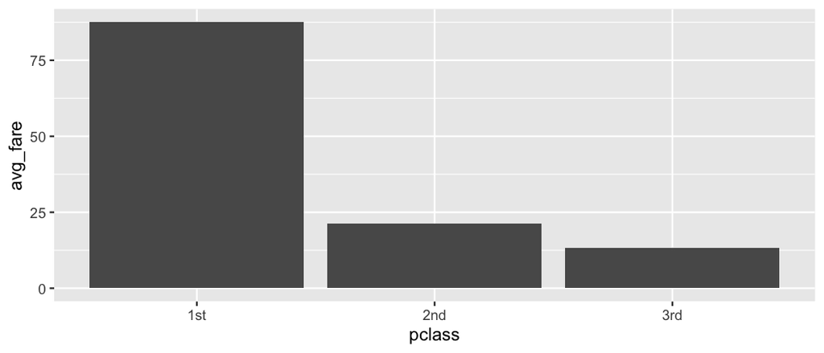

```r
myQuery <- "select pclass, avg(fare) as avg_fare from titanic
              group by pclass;"
myData <- dbGetQuery(con, myQuery)
library(ggplot2)
ggplot(myData, aes(pclass, avg_fare)) + geom_bar(stat="identity")
```

### What if you don't know SQL

- `R` package `dplyr` considers database tables as data frame

```r
library(dplyr) # you need to install package dbplyr as well
conDplyr = src_mysql(dbname = "trainingDB", user = "training",
                password = "training123", host = "localhost")

myData <- conDplyr %>%
  tbl("titanic") %>%
  select(pclass, sex, age, fare, survived, parch) %>%
  filter(survived==0) %>%
  collect()

head(myData)
```

```
# A tibble: 6 x 6
  pclass sex      age  fare survived parch
  <chr>  <chr>  <dbl> <dbl> <chr>    <int>
1 1st    female     2 152.  0            2
2 1st    male      30 152.  0            2
3 1st    female    25 152.  0            2
4 1st    male      39   0   0            0
5 1st    male      71  49.5 0            0
6 1st    male      47 228.  0            0
```

### Using dplyr to manipulate database table

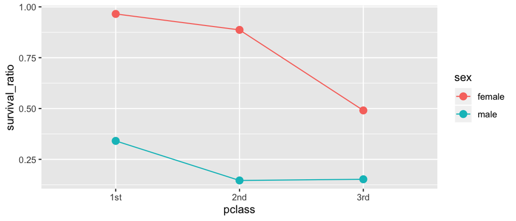

```r
myData <- conDplyr %>%
  tbl("titanic") %>%
  select(pclass, sex, survived) %>%
  group_by(pclass, sex) %>%
  summarise(survival_ratio = mean(survived)) %>%
  collect()

ggplot(myData, aes(pclass,survival_ratio, color=sex, group=sex)) +
  geom_point(size=3) + geom_line()
```

### Lazy operation by dplyr

- How does being lazy help?
  - `dplyr` delays the actual operation until necessary
  - it loads data onto `R` from the database only when we need it
  - these sequences of commands do nothing and do not query database table yet

```r
myDF <- tbl(conDplyr,"titanic")
myDF1 <- filter(myDF, fare > 150)
myDF2 <- select(myDF1, pclass,sex,age,fare)
myDF3 <- group_by(myDF2, pclass,sex)
myDF4 <- summarise(myDF3,
                   avg_age = mean(age, na.rm=TRUE),
                   avg_fare = mean(fare, na.rm=TRUE))
```

- Only following command will trigger the actual loading of the data onto `R`

```r
head(data.frame(myDF4), n=2)
```

```
  pclass    sex  avg_age avg_fare
1    1st female 35.15152 232.9025
2    1st   male 37.58854 248.7482
```

### View the query run by dplyr

```r
show_query(myDF4)
```

```
<SQL>
SELECT `pclass`, `sex`, AVG(`age`) AS `avg_age`, AVG(`fare`) AS `avg_fare`
FROM (SELECT `pclass`, `sex`, `age`, `fare`
FROM (SELECT *
FROM `titanic`
WHERE (`fare` > 150.0)) `dbplyr_005`) `dbplyr_006`
GROUP BY `pclass`, `sex`
```

```r
explain(myDF4)
```

```
<SQL>
SELECT `pclass`, `sex`, AVG(`age`) AS `avg_age`, AVG(`fare`) AS `avg_fare`
FROM (SELECT `pclass`, `sex`, `age`, `fare`
FROM (SELECT *
FROM `titanic`
WHERE (`fare` > 150.0)) `dbplyr_007`) `dbplyr_008`
GROUP BY `pclass`, `sex`

<PLAN>
  id select_type   table partitions type possible_keys  key key_len  ref
1  1      SIMPLE titanic       <NA>  ALL          <NA> <NA>    <NA> <NA>
  rows filtered                        Extra
1 1309    33.33 Using where; Using temporary
```

### Trigger the loading of data using collect()

```r
collect(myDF4)
```

```
# A tibble: 2 x 4
# Groups:   pclass [1]
  pclass sex    avg_age avg_fare
  <chr>  <chr>    <dbl>    <dbl>
1 1st    female    35.2     233.
2 1st    male      37.6     249.
```

```r
head(collect(myDF2))
```

```
# A tibble: 6 x 4
  pclass sex       age  fare
  <chr>  <chr>   <dbl> <dbl>
1 1st    female 29      211.
2 1st    male    0.917  152.
3 1st    female  2      152.
4 1st    male   30      152.
5 1st    female 25      152.
6 1st    male   47      228.
```

### The whole process can be run by chaining

```r
conDplyr %>%
  tbl("titanic") %>%
  filter(fare > 150) %>%
  select(pclass,sex,age,fare) %>%
  group_by(pclass,sex) %>%
  summarise(avg_age = mean(age),
            avg_fare = mean(fare))
```

```
# Source:   lazy query [?? x 4]
# Database: mysql 8.0.18 [training@localhost:/trainingDB]
# Groups:   pclass
  pclass sex    avg_age avg_fare
  <chr>  <chr>    <dbl>    <dbl>
1 1st    female    35.2     233.
2 1st    male      37.6     249.
```

### Other functions in dplyr

```r
db_list_tables(con)
```

```
[1] "titanic"
```

- study the following functions  
  `db_query_rows(), db_explain(), db_analyze()`
- you can create, alter, insert tables using dplyr  
  `db_create_table(), db_insert_into()`

### Connecting various databases

- While package RMySQL provides connectivity to MySQL database, you can use package `RODBC` to connect various databases.
- `ODBC` stands for Open Database Connectivity
  - provides API to access DBMS
  - `RODBC` does the same for `R`

```r
install.packages("RODBC")
library(ODBC)
```

- `dplyr` can work under `ODBC` connection.

### Reading assignment and references

- MySQL 5.7 Reference Manual  
  http://dev.mysql.com/doc/refman/5.7/en/index.html
- For details about `RMySQL` functionality review this document. For example, this package provides functions to upload data from directly dataframe.  
  http://cran.r-project.org/web/packages/RMySQL/RMySQL.pdf
- `dplyr` vignettes that describe database issues  
  http://cran.r-project.org/web/packages/dplyr/vignettes/databases.html